# Homework 3

Lauren Smith

October 1, 2019

# Task Option 1

*Report the absolute and/or relative abundance of countries with low life expectancy over time by continent: Compute some measure of worldwide life expectancy – you decide – a mean or median or some other quantile or perhaps your current age. Then determine how many countries on each continent have a life expectancy less than this benchmark, for each year.*

Use summarize() to calculate the grand mean of life expectancy for the entire world.

```r
world_lifeExp <- gapminder %>%
  summarize(mean = mean(lifeExp))
```

Then filter out the entries that have a life expectancy that is less than the world mean, and create a tibble to display the data.

```r
lowlifeExp <- gapminder %>%
  select(continent, country, year, lifeExp) %>%
  group_by(lifeExp) %>%
  filter(lifeExp < world_lifeExp)
print(lowlifeExp)
```

```
## # A tibble: 809 x 4
## # Groups:   lifeExp [797]
##    continent country      year lifeExp
##    <fct>     <fct>       <int>   <dbl>
##  1 Asia      Afghanistan  1952    28.8
##  2 Asia      Afghanistan  1957    30.3
##  3 Asia      Afghanistan  1962    32.0
##  4 Asia      Afghanistan  1967    34.0
##  5 Asia      Afghanistan  1972    36.1
##  6 Asia      Afghanistan  1977    38.4
##  7 Asia      Afghanistan  1982    39.9
##  8 Asia      Afghanistan  1987    40.8
##  9 Asia      Afghanistan  1992    41.7
## 10 Asia      Afghanistan  1997    41.8
## # ... with 799 more rows
```

Plot the number of countries in each year for each continent that have a life expectancy that is less than the world mean.

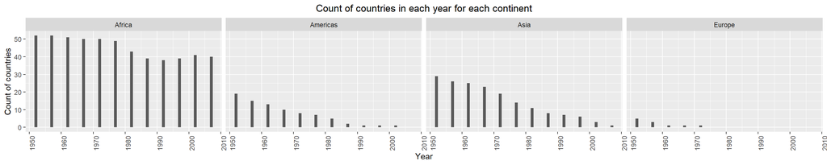

```r
ggplot(lowlifeExp, aes(year, group = country)) +
  geom_bar(width = 0.9) +
  facet_wrap(~continent, nrow = 1) +
  theme(plot.title = element_text(hjust = 0.5), axis.text.x = element_text(angle = 90)) +
  labs(title = "Count of countries in each year for each continent", x = "Year", y = "Count of countries")
```

Description:

The tibble and bar graphs above show the number of countries in each continent and year that have a life expectancy that is less than the average worldwide life expectancy. The graphs show that, for the most part, the number of countries with life expectancy lower than the worldwide averages is getting lower. In other words, life expectancy is generally increasing through time.

# Task Option 2

*Get the maximum and minimum of GDP per capita for all continents.*

Get the maximum and minimum of GDP per capita for all continents, and create a tibble to display the data.

```r
minmax_gdp <- gapminder %>%
  group_by(continent) %>%
  summarize(max_gdp = max(gdpPercap),
            min_gdp = min(gdpPercap))
print(minmax_gdp)
```

```
## # A tibble: 5 x 3
##   continent max_gdp min_gdp
##   <fct>       <dbl>   <dbl>
## 1 Africa     21951.    241.
## 2 Americas   42952.   1202.
## 3 Asia      113523.    331
## 4 Europe     49357.    974.
## 5 Oceania    34435.  10040.
```

Create a boxplot that shows the minimum, maximum, and spread of the data.

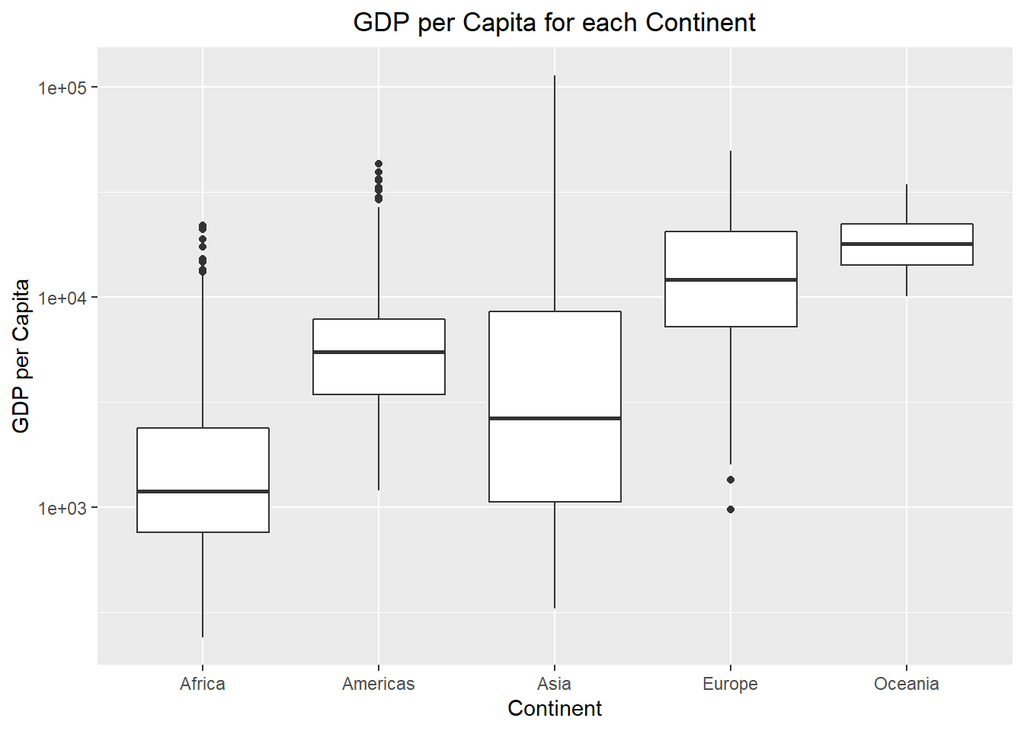

```r
gapminder %>%
  group_by(continent)%>%
  ggplot(aes(continent, gdpPercap)) +
  geom_boxplot() +
  scale_y_log10() +
  labs(title = "GDP per Capita for each Continent", x = "Continent", y = "GDP per Capita") +
  theme(plot.title = element_text(hjust = 0.5))
```

# Task Option 5

*How is life expectancy changing over time on different continents?*

```r
cont_lifeExp <- gapminder %>%
  group_by(continent, year) %>%
  summarize(lifeExp_cont = mean(lifeExp))
print(cont_lifeExp)
```

```
## # A tibble: 60 x 3
## # Groups:   continent [5]
##    continent  year lifeExp_cont
##    <fct>     <int>        <dbl>
##  1 Africa     1952         39.1
##  2 Africa     1957         41.3
##  3 Africa     1962         43.3
##  4 Africa     1967         45.3
##  5 Africa     1972         47.5
##  6 Africa     1977         49.6
##  7 Africa     1982         51.6
##  8 Africa     1987         53.3
##  9 Africa     1992         53.6
## 10 Africa     1997         53.6
## # ... with 50 more rows
```

Plot the average life expectancy for each continent through time.

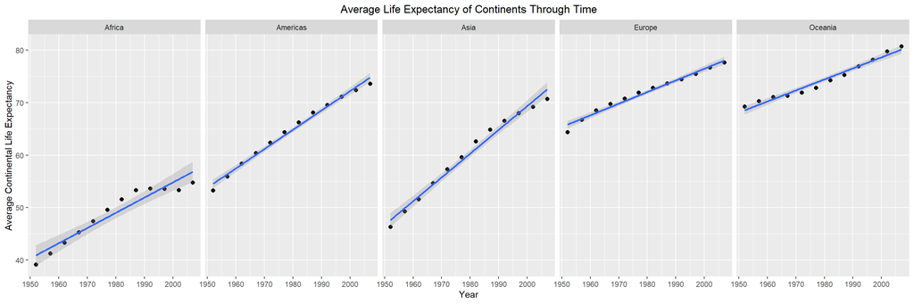

```r
ggplot(cont_lifeExp, aes(year, lifeExp_cont, group = continent)) +
  geom_point(size = 2) +
  geom_smooth(method = 'lm', alpha = 0.3) +
  facet_wrap(~continent, nrow = 1) +
  labs(title = "Average Life Expectancy of Continents Through Time", x = "Year", y = "Average Continental Life Expectancy") +
  theme(plot.title = element_text(hjust = 0.5))
```